# Lab 2 — Visualizing Ecuador's Export Time Series

# Part 6 — Activities

Parts 1–5 explored Ecuador's **primary exports** (PRIMARIOS) — the raw commodities that form the backbone of the country's trade. In these activities you apply the same visualization techniques to Ecuador's **industrialized exports** (INDUSTRIALIZADOS) — the ten categories of processed and manufactured goods. This lets you practice each technique on a new product group and draw comparisons between the two halves of Ecuador's export economy.

Complete each activity independently using `df_monthly` (or `df_annual` where indicated). **Each activity is worth the same number of points.**

Where a task asks for an interpretation, write your answer in a markdown cell after your code.

## 🎯 Activity 1: Time Series Decomposition — Industrialized Products

In Part 1 we decomposed **Petroleum** (a primary product). Now apply the same technique to **Processed Cocoa** (`Processed_Cocoa`), an industrialized product that directly derives from Ecuador's fastest-growing primary export.

Using `df_monthly`:

1. Plot the raw monthly series of `Processed_Cocoa` as a line chart.
2. Compute and overlay a **3-month centered rolling mean** to approximate the trend.
3. Compute the **deviation from trend** (raw − rolling mean) and plot it in a second panel.
4. In a markdown cell: does Processed Cocoa show a seasonal pattern? How does its pattern compare to raw Cocoa (from Part 1's decomposition example)? What does this tell you about the relationship between the primary and industrialized stages of the cocoa value chain?

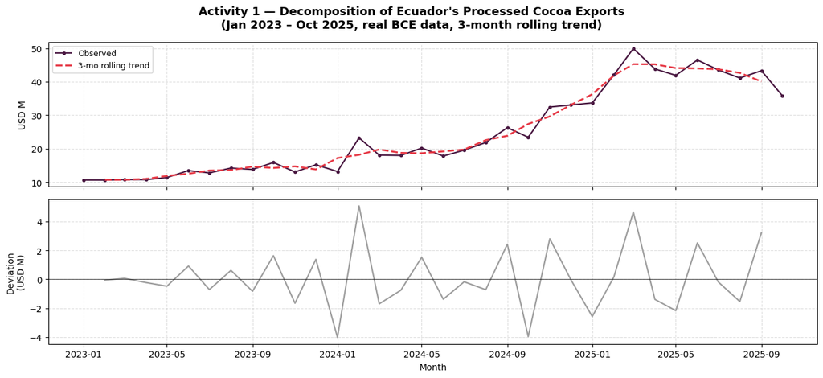

```
Processed Cocoa — mean: 24.7 USD M | std: 12.9 USD M | coefficient of variation: 52.2%
```

```python
pc = df_monthly.set_index('date')['Processed_Cocoa']

# TREND: 3-month centered rolling mean (shorter window than Petroleum's 6-month, appropriate since Processed_Cocoa may have a different noise profile)
pc_trend = pc.rolling(window=3, center=True).mean()

# DEVIATION FROM TREND: raw − rolling mean (seasonality + noise combined, since the activity only asks for a 2-panel view, not a full 4-way split)
pc_deviation = pc - pc_trend

fig, axes = plt.subplots(2, 1, figsize=(13, 6), sharex=True)
fig.suptitle("Activity 1 — Decomposition of Ecuador's Processed Cocoa Exports\n"
             "(Jan 2023 – Oct 2025, real BCE data, 3-month rolling trend)",
             fontsize=13, fontweight='bold')

# Panel 1: raw observed series + trend overlay
axes[0].plot(pc.index, pc.values, color=ind_colors['Processed_Cocoa'],
             linewidth=1.6, marker='o', markersize=3, label='Observed')
axes[0].plot(pc_trend.index, pc_trend.values, color='#e63946',
             linewidth=2, linestyle='--', label='3-mo rolling trend')
axes[0].set_ylabel('USD M')
axes[0].legend(fontsize=9)
axes[0].grid(True, linestyle='--', alpha=0.4)

# Panel 2: deviation from trend
axes[1].plot(pc_deviation.index, pc_deviation.values, color='#9e9e9e', linewidth=1.6)
axes[1].axhline(0, color='black', linewidth=0.5)
axes[1].set_ylabel('Deviation\n(USD M)')
axes[1].set_xlabel('Month')
axes[1].grid(True, linestyle='--', alpha=0.4)

plt.tight_layout()
plt.show()

# Quick numeric summary to support the interpretation
print(f"Processed Cocoa — mean: {pc.mean():.1f} USD M | std: {pc.std():.1f} USD M | "
      f"coefficient of variation: {pc.std()/pc.mean()*100:.1f}%")
```

This pattern is similar to that of raw Cocoa analyzed in Part 1. Both raw and Processed Cocoa exhibit strong growth and considerable short-term fluctuations, but neither presents a stable monthly pattern that repeats clearly across the years. Raw Cocoa also showed one of the largest increases among primary products, with substantial variation across the period. Processed Cocoa appears to follow a broadly similar trajectory, suggesting that the growth of cocoa processing has occurred alongside the expansion of raw cocoa exports.

The similarity between the two series indicates that the primary and industrialized stages of Ecuador’s cocoa value chain are closely connected. As the production and export value of raw Cocoa increase, Processed Cocoa exports also tend to expand, suggesting that the industrial stage is benefiting from the growth of the primary sector rather than evolving independently from it. However, this visual similarity demonstrates association, not causation, and should ideally be confirmed through a direct comparison of growth rates, market shares, and correlations between both series.

Overall, the results suggest that Ecuador is beginning to capture more value through cocoa processing, but the industrialized stage remains considerably smaller than the primary stage. This means that much of the potential value added is still not retained domestically and supports the recommendation to strengthen processing infrastructure, innovation, certification, and access to higher-value international markets.

## 🎯 Activity 2: Visualization Taxonomies — All 10 Industrialized Products

In Part 2 we applied shared-space and split-space taxonomies to primary products. Now apply both to **all 10 industrialized products**.

Using `df_monthly`:

1. Build a **shared-space line chart** with all 10 industrialized products on one axis. Use `ind_colors` for the color palette.
2. Build a **split-space small-multiples** grid (2×5) with one panel per industrialized product, `sharey=True`.
3. In a markdown cell: which taxonomy works better for industrialized products? Is the scale problem (dominant product compressing the others) worse or better than it was for primary products, and why?

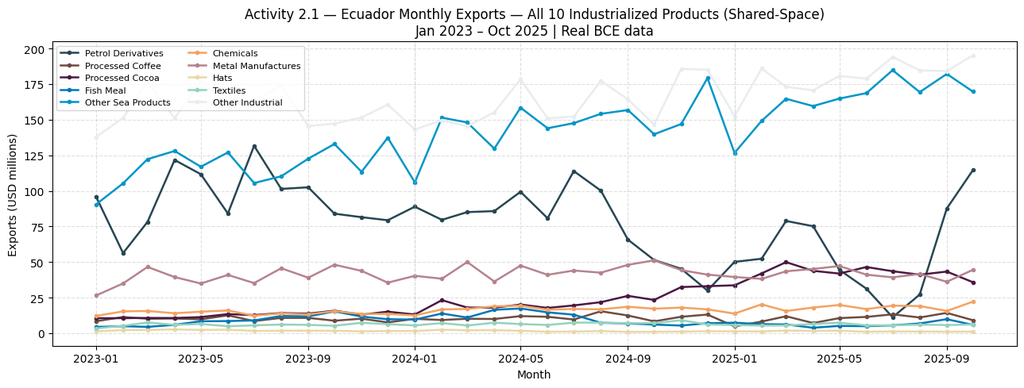

```
Compare: does one product dominate and compress the others, the way
Petroleum did for primary products in Part 2.1?
```

```python
# Activity 2.1 — Shared-space: ALL 10 industrialized products on one axis
fig, ax = plt.subplots(figsize=(13, 5))
for cat in industrialized_products:
    ax.plot(df_monthly['date'], df_monthly[cat],
            label=cat.replace('_', ' '), color=ind_colors[cat],
            linewidth=1.8, marker='o', markersize=3)

for yr in [2024, 2025]:
    ax.axvline(pd.Timestamp(f'{yr}-01-01'), color='#ccc', linewidth=0.8, linestyle=':')

ax.set_title("Activity 2.1 — Ecuador Monthly Exports — All 10 Industrialized Products (Shared-Space)\n"
             "Jan 2023 – Oct 2025 | Real BCE data", fontsize=12)
ax.set_xlabel('Month'); ax.set_ylabel('Exports (USD millions)')
ax.legend(loc='upper left', fontsize=8, ncol=2)
ax.grid(True, linestyle='--', alpha=0.4)
plt.tight_layout(); plt.show()

print("Compare: does one product dominate and compress the others, the way")
print("Petroleum did for primary products in Part 2.1?")
```

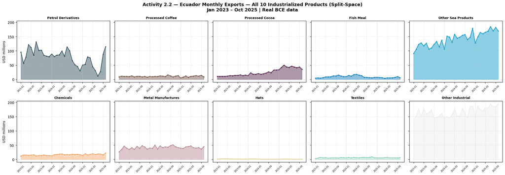

```python
# Activity 2.2 — Split-space: ALL 10 industrialized products, 2×5 grid
fig, axes = plt.subplots(2, 5, figsize=(20, 7), sharey=True)
fig.suptitle("Activity 2.2 — Ecuador Monthly Exports — All 10 Industrialized Products (Split-Space)\n"
             "Jan 2023 – Oct 2025 | Real BCE data", fontsize=13, fontweight='bold')

for ax, cat in zip(axes.flat, industrialized_products):
    ax.fill_between(df_monthly['date'], df_monthly[cat],
                     alpha=0.45, color=ind_colors[cat])
    ax.plot(df_monthly['date'], df_monthly[cat],
            color=ind_colors[cat], linewidth=1.4, marker='o', markersize=2)
    for yr in [2024, 2025]:
        ax.axvline(pd.Timestamp(f'{yr}-01-01'), color='#ccc', linewidth=0.8, linestyle=':')
    ax.set_title(cat.replace('_', ' '), fontsize=9, fontweight='bold')
    ax.tick_params(axis='x', rotation=45, labelsize=6)
    ax.grid(True, linestyle='--', alpha=0.3)

for row in range(2):
    axes[row, 0].set_ylabel('USD millions')

plt.tight_layout()
plt.show()
```

## 🎯 Activity 3: Heatmap — All 10 Industrialized Products

In Part 3.1 we built a heatmap comparing Total Primary vs. Total Industrialized. Now drill into the industrialized group itself.

Using `df_monthly`:

1. Build a **heatmap** with rows = the 10 industrialized products, columns = month (Jan–Dec), color = average export value in USD millions. Use the `Blues` colormap.
2. Annotate cells with values (`annot=True`, `fmt='.1f'`).
3. In a markdown cell: which industrialized products have the strongest seasonal patterns? Compare with the primary product heatmap from Part 3.1 — does the industrialized group show more or less seasonality overall?

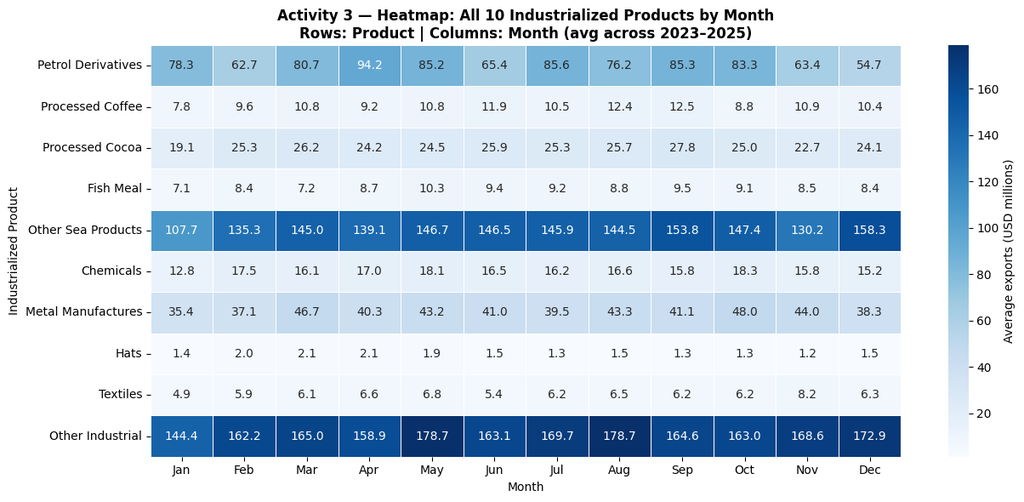

```
Seasonal strength (month-to-month range as % of average) — highest first:
Hats                  56.0
Textiles              53.1
Petrol Derivatives    51.9
Processed Coffee      45.2
Fish Meal             36.5
Other Sea Products    35.7
Processed Cocoa       35.0
Chemicals             33.7
Metal Manufactures    30.2
Other Industrial      20.7
dtype: float64
```

```python
month_labels = ['Jan','Feb','Mar','Apr','May','Jun',
                 'Jul','Aug','Sep','Oct','Nov','Dec']

# Pivot: mean value per product per calendar month, transposed so products are rows and months are columns (as the activity specifies)
pivot_ind = df_monthly.groupby('month')[industrialized_products].mean().T
pivot_ind.columns = month_labels
pivot_ind.index = [c.replace('_', ' ') for c in pivot_ind.index]

fig, ax = plt.subplots(figsize=(13, 6))
sns.heatmap(pivot_ind, cmap='Blues', annot=True, fmt='.1f',
            linewidths=0.4, linecolor='white',
            cbar_kws={'label': 'Average exports (USD millions)'}, ax=ax)
ax.set_title("Activity 3 — Heatmap: All 10 Industrialized Products by Month\n"
             "Rows: Product | Columns: Month (avg across 2023–2025)", fontsize=12, fontweight='bold')
ax.set_xlabel('Month'); ax.set_ylabel('Industrialized Product')
plt.tight_layout()
plt.show()

# Quantify seasonal strength per product: range (max - min month) as a % of that product's own average — a product with no seasonality has a small range relative to its mean; a strongly seasonal one has a large range.
seasonal_strength = ((pivot_ind.max(axis=1) - pivot_ind.min(axis=1)) / pivot_ind.mean(axis=1) * 100).sort_values(ascending=False)
print("Seasonal strength (month-to-month range as % of average) — highest first:")
print(seasonal_strength.round(1))
```

Compared with the primary-product heatmap from Part 3.1, the industrialized group appears less seasonal when viewed only at the aggregate level. However, the product-level analysis reveals a more complex picture. Seven of the ten individual industrialized products display moderate to strong seasonal variation, in some cases comparable to or greater than that of several primary products. The key difference is that their peaks occur in different months. For example, Petroleum Derivatives peak in April and September, Other Sea Products in September and December, and Textiles in May and November.

Because these seasonal peaks are not synchronized, they tend to offset one another when all products are combined into the Total Industrialized series. As a result, the aggregate heatmap appears relatively flat even though many individual components have clear seasonal patterns. This is a case of aggregation cancellation: the absence of visible seasonality in the total does not mean that the individual products lack seasonality, but rather that their cycles occur at different times and partially cancel each other out.

Therefore, the industrialized group shows less seasonality overall at the aggregate level, but substantial seasonality at the individual-product level. This also demonstrates why detailed space-filling views are necessary to complement aggregated heatmaps. Just as split-space revealed patterns hidden in the shared-space chart, the product-level heatmap uncovers seasonal behavior that is obscured when all industrialized products are summed together.

## 🎯 Activity 4: Interactive Chart — All 10 Industrialized Products

Build an **interactive Plotly line chart** of all 10 industrialized products from `df_monthly` that:

1. Uses `ind_colors` for colors, hover tooltips (product name, date, value in USD M), and `hovermode='x unified'`.
2. Adds a **range selector** (6M, 1Y, All) and a **range slider**.
3. In a markdown cell: use the 1Y zoom to focus on 2024. Which industrialized product was most volatile month-to-month? Which showed the most consistent upward trend? How does the volatility of industrialized products compare to what you observed for primary products in Part 4.1?

```python
fig = go.Figure()
for cat in industrialized_products:
    fig.add_trace(go.Scatter(
        x=df_monthly['date'], y=df_monthly[cat],
        mode='lines+markers',
        name=cat.replace('_', ' '),
        line=dict(color=ind_colors[cat], width=1.8),
        marker=dict(size=3),
        hovertemplate='<b>' + cat.replace('_', ' ') + '</b><br>%{x|%b %Y}<br>%{y:,.1f} USD M<extra></extra>'
    ))

fig.update_layout(
    title="Activity 4 — Ecuador Monthly Industrialized Exports — All 10 Products (Interactive)<br>"
          "<sup>Click legend to filter | Drag to zoom | 6M/1Y buttons | Hover for exact values</sup>",
    xaxis_title='Month', yaxis_title='Exports (USD millions)',
    hovermode='x unified',
    height=540,
    legend=dict(x=1.01, y=1),
    xaxis=dict(
        rangeslider=dict(visible=True),
        rangeselector=dict(buttons=[
            dict(count=6, label='6M', step='month', stepmode='backward'),
            dict(count=1, label='1Y', step='year', stepmode='backward'),
            dict(step='all', label='All')])))
fig.show()
```

[output not shown]

```python
# Support code: quantify volatility and trend consistency for 2024 specifically, since the markdown question asks you to zoom into 2024 with the 1Y button.
m24_ind = df_monthly[df_monthly['year'] == 2024]

print("2024 monthly volatility and trend — Industrialized products")
print(f"{'Product':<22}{'CV (%)':>10}{'Trend slope':>15}{'R² (fit)':>12}")
for cat in industrialized_products:
    series = m24_ind[cat].values
    cv = series.std() / series.mean() * 100
    x = np.arange(len(series))
    slope, intercept = np.polyfit(x, series, 1)
    pred = slope * x + intercept
    ss_res = ((series - pred) ** 2).sum()
    ss_tot = ((series - series.mean()) ** 2).sum()
    r2 = 1 - ss_res / ss_tot if ss_tot > 0 else 0
    print(f"{cat.replace('_',' '):<22}{cv:>9.1f}%{slope:>15.2f}{r2:>12.2f}")
```

```
2024 monthly volatility and trend — Industrialized products
Product                   CV (%)    Trend slope    R² (fit)
Petrol Derivatives         30.6%          -4.40        0.41
Processed Coffee           16.8%           0.21        0.16
Processed Cocoa            25.6%           1.35        0.67
Fish Meal                  38.0%          -0.76        0.42
Other Sea Products         11.4%           2.91        0.36
Chemicals                   9.7%           0.18        0.14
Metal Manufactures         10.2%           0.41        0.10
Hats                       31.1%          -0.10        0.49
Textiles                   14.7%           0.14        0.23
Other Industrial            9.6%           2.93        0.43
```

Using the 1Y zoom to focus on 2024, Fish Meal was the most volatile industrialized product on a month-to-month basis, with a coefficient of variation of approximately 38.0%. It was followed by Hats at 31.1% and Petroleum Derivatives at 30.6%. This is not immediately obvious from the interactive chart because Fish Meal operates on a much smaller scale, generally below USD 20 million, while larger categories such as Other Sea Products produce more visually noticeable movements. For this reason, the coefficient of variation is a more appropriate measure than visual inspection alone, since it evaluates volatility relative to each product’s own average.

The industrialized product with the most consistent upward trend was Processed Cocoa. It had a positive monthly slope of approximately 1.35 and the highest coefficient of determination, with an (R^2) of 0.67. This indicates that Processed Cocoa did not simply increase during 2024, but followed a comparatively steady and orderly upward trajectory, with less fluctuation around the trend line. This finding is consistent with the earlier decomposition analysis, which showed that the series was dominated by a strong trend rather than by a stable seasonal pattern.

Overall, the results suggest that industrialized products tend to be more stable than primary commodities, but this depends on the type of product. Industrialized goods that remain closely linked to volatile commodities, such as Petroleum Derivatives, can inherit much of the instability of the primary stage. In contrast, more differentiated manufactured products, including Textiles, Chemicals, and Metal Manufactures, appear considerably more stable. This supports the argument that diversification should focus not only on industrialization in general, but specifically on manufacturing activities that generate higher value added and are less exposed to commodity-price volatility.

## 🎯 Activity 5: Parallel Coordinates — All 10 Industrialized Products

In Part 3.6 we built parallel coordinates for all 11 primary products. Now apply the same technique to the 10 industrialized products.

Using `df_monthly`:

1. Build a **Plotly parallel coordinates** chart with all 10 industrialized products as axes. Color by year (2023=teal, 2024=yellow, 2025=red). Use `ind_colors` values as the colorscale where possible, or use the year-based colorscale from Part 3.6.
2. In a markdown cell: identify one **positive correlation** and one **negative correlation** between industrialized products. Do the correlated pairs make economic sense? Compare the overall structure of this chart with the primary products' parallel coordinates in Part 3.6 — which group shows more correlated co-movement?

```python
fig = px.parallel_coordinates(
    df_monthly,
    dimensions=industrialized_products,
    color='year',
    color_continuous_scale=[[0.0, '#2a9d8f'], [0.5, '#e9c46a'], [1.0, '#e63946']],
    labels={c: c.replace('_', ' ') for c in industrialized_products},
    title='Activity 5 — Parallel Coordinates — All 10 Industrialized Products by Month (2023–2025)'
          '<sup>Each line = one month | Teal=2023 | Yellow=2024 | Red=2025</sup>'
)
fig.update_layout(height=550)
fig.show()

# Correlation highlights to support the written interpretation
print("Correlation highlights (10 industrialized products):")
corr_ind = df_monthly[industrialized_products].corr().round(2)
pairs_ind = [(r, c, corr_ind.loc[r, c]) for r in industrialized_products for c in industrialized_products
             if r < c and (corr_ind.loc[r, c] > 0.5 or corr_ind.loc[r, c] < -0.3)]
pairs_ind.sort(key=lambda x: abs(x[2]), reverse=True)
for r, c, v in pairs_ind[:8]:
    direction = 'positive' if v > 0 else 'negative'
    print(f"  {r} ↔ {c}: {v:+.2f} ({direction})")

# Also compute overall "co-movement strength" for comparison with primary products: average absolute correlation across all pairs, excluding self-correlation.
avg_abs_corr_ind = corr_ind.where(~np.eye(len(industrialized_products), dtype=bool)).abs().mean().mean()
corr_prim = df_monthly[primary_products].corr()
avg_abs_corr_prim = corr_prim.where(~np.eye(len(primary_products), dtype=bool)).abs().mean().mean()
print(f"\nAverage |correlation| — Industrialized: {avg_abs_corr_ind:.2f} | Primary: {avg_abs_corr_prim:.2f}")
```

[output not shown]

```
Correlation highlights (10 industrialized products):
  Other_Sea_Products ↔ Processed_Cocoa: +0.81 (positive)
  Chemicals ↔ Other_Sea_Products: +0.72 (positive)
  Other_Industrial ↔ Other_Sea_Products: +0.66 (positive)
  Other_Industrial ↔ Processed_Cocoa: +0.65 (positive)
  Chemicals ↔ Other_Industrial: +0.61 (positive)
  Petrol_Derivatives ↔ Processed_Cocoa: -0.60 (negative)
  Chemicals ↔ Processed_Cocoa: +0.58 (positive)
  Other_Sea_Products ↔ Petrol_Derivatives: -0.48 (negative)

Average |correlation| — Industrialized: 0.30 | Primary: 0.17
```

A clear positive correlation appears between Other Sea Products and Processed Cocoa, with a coefficient of approximately +0.81, the strongest positive relationship in the industrialized group. However, this pair does not have an obvious direct productive link, since processed seafood and processed cocoa do not share the same inputs, harvesting cycle, or value chain. The relationship is more likely explained by a common upward trend: both categories increased steadily between 2023 and 2025, so they move together over time even though one does not necessarily cause the other to grow. A similar interpretation applies to other positive pairs, such as Chemicals and Other Sea Products.

The strongest negative correlation is between Petroleum Derivatives and Processed Cocoa, at approximately −0.60. This relationship is economically interpretable, but not because the two products directly compete. Rather, they followed opposite trajectories during the period: Processed Cocoa grew consistently, while Petroleum Derivatives declined and experienced a sharp fall toward the end of 2024. Their negative correlation therefore reflects two contrasting export trends occurring at the same time—expansion in the cocoa value chain and contraction in petroleum-based industrial exports.

The correlated pairs make partial economic sense, but they should not automatically be interpreted as causal relationships. The positive correlations are likely driven mainly by shared trends and common macroeconomic conditions rather than direct production links. In contrast, the negative relationship involving Petroleum Derivatives is meaningful as a description of structural divergence: one industrialized sector was expanding while another was losing momentum. Correlation in this chart should therefore be understood as co-movement, not proof that changes in one product directly cause changes in another.

Compared with the parallel-coordinates chart for primary products in Part 3.6, the industrialized group shows stronger overall co-movement. The average absolute correlation is approximately 0.30 for industrialized products, compared with about 0.17 for primary products. This difference is economically plausible because primary commodities such as Petroleum, Bananas, Shrimp, Cocoa, and Coffee are affected by distinct harvest cycles, international prices, climatic conditions, and supply shocks. Industrialized products, by contrast, may respond more similarly to common factors such as manufacturing activity, investment, export demand, logistics, and conditions in shared destination markets. As a result, their lines tend to move together more frequently, even when there is no direct productive connection between the individual products.

## 🎯 Activity 6: Storytelling — Build a Narrative About Industrialized Exports

Apply Knaflic's six lessons (demonstrated in Part 5 using primary products) to build a persuasive chart about **one or two industrialized products**.

1. Write a one-sentence **Big Idea** (audience + message + call to action) in a markdown cell.
2. Choose **one or two industrialized products** that tell an interesting story. Build a single polished chart using `df_annual` (for the 2020–2024 arc) applying all six lessons:
   - Line chart (appropriate display for trends)
   - Decluttered (no border spines, no legend — use direct labels)
   - Focused attention (your chosen product(s) in color, rest in `#cccccc`(gray color))
   - Sentence-style title stating the conclusion
   - One annotation naming the key quantitative insight
3. In a markdown cell: what policy action does your chart argue for? How does the story of your chosen industrialized product complement or contrast with the cocoa narrative from Part 5?

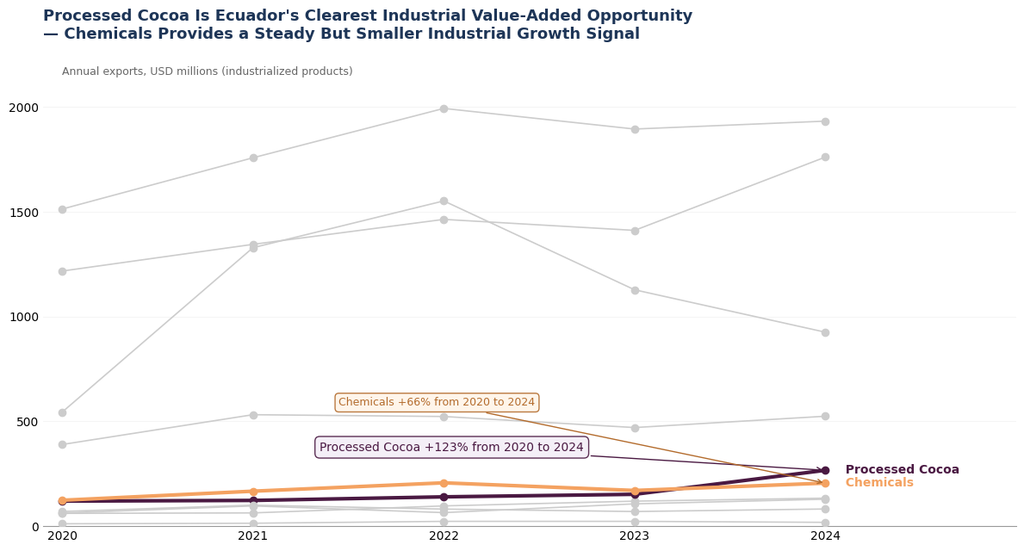

```
Processed Cocoa annual values:
 year  Processed_Cocoa
 2020       119.565458
 2021       122.823278
 2022       139.899225
 2023       152.006223
 2024       266.739928

Chemicals annual values:
 year  Chemicals
 2020 123.611429
 2021 166.867546
 2022 206.832374
 2023 170.325504
 2024 205.511032
```

```python
# Activity 6: Storytelling — Industrialized exports
# Big idea: Ecuador should invest in cocoa processing because Processed_Cocoa is the clearest value-added industrial export story.
# Chemicals is shown as a secondary industrial benchmark: steady growth, but a less dramatic narrative than cocoa.

GRAY = '#cccccc'
HL = {
    'Processed_Cocoa': '#4a1942',
    'Chemicals': '#f4a261',
}

fig, ax = plt.subplots(figsize=(12, 6.5))

for product in industrialized_products:
    color = HL.get(product, GRAY)
    linewidth = 3.0 if product in HL else 1.2
    ax.plot(
        df_annual['year'],
        df_annual[product],
        marker='o',
        color=color,
        linewidth=linewidth,
        zorder=3,
    )
    if product in HL:
        ax.text(
            df_annual['year'].iloc[-1] + 0.06,
            df_annual[product].iloc[-1],
            '  ' + product.replace('_', ' '),
            color=color,
            fontsize=10,
            va='center',
            fontweight='bold',
        )

# Quantify the key point so the chart tells a concrete story.
pc_2020 = float(df_annual.loc[df_annual['year'] == 2020, 'Processed_Cocoa'].iloc[0])
pc_2024 = float(df_annual.loc[df_annual['year'] == 2024, 'Processed_Cocoa'].iloc[0])
chem_2020 = float(df_annual.loc[df_annual['year'] == 2020, 'Chemicals'].iloc[0])
chem_2024 = float(df_annual.loc[df_annual['year'] == 2024, 'Chemicals'].iloc[0])

ax.annotate(
    f'Processed Cocoa +{(pc_2024 / pc_2020 - 1) * 100:.0f}% from 2020 to 2024',
    xy=(2024, pc_2024),
    xytext=(2021.35, pc_2024 * 1.35),
    fontsize=10,
    color='#4a1942',
    bbox=dict(boxstyle='round,pad=0.4', fc='#f3eef7', ec='#4a1942', alpha=0.9),
    arrowprops=dict(arrowstyle='->', color='#4a1942'),
)

ax.annotate(
    f'Chemicals +{(chem_2024 / chem_2020 - 1) * 100:.0f}% from 2020 to 2024',
    xy=(2024, chem_2024),
    xytext=(2021.45, chem_2024 * 2.8),
    fontsize=9,
    color='#b36b2c',
    bbox=dict(boxstyle='round,pad=0.35', fc='#fff4e8', ec='#b36b2c', alpha=0.9),
    arrowprops=dict(arrowstyle='->', color='#b36b2c'),
)

for spine in ['top', 'right', 'left']:
    ax.spines[spine].set_visible(False)
ax.spines['bottom'].set_color('#999')
ax.tick_params(length=0)
ax.grid(axis='y', linestyle='-', alpha=0.12)
ax.set_xticks(df_annual['year'])
ax.set_xlim(df_annual['year'].min() - 0.1, df_annual['year'].max() + 1.0)
ax.set_ylim(0, df_annual[industrialized_products].max().max() * 1.15)

ax.set_title(
    "Processed Cocoa Is Ecuador's Clearest Industrial Value-Added Opportunity\n"
    "— Chemicals Provides a Steady But Smaller Industrial Growth Signal",
    fontsize=13,
    fontweight='bold',
    loc='left',
    color='#1d3557',
)
ax.text(
    df_annual['year'].min(),
    df_annual[industrialized_products].max().max() * 1.08,
    'Annual exports, USD millions (industrialized products)',
    fontsize=9,
    color='#666',
)

plt.tight_layout()
plt.show()

print('Processed Cocoa annual values:')
print(df_annual[['year', 'Processed_Cocoa']].to_string(index=False))
print('\nChemicals annual values:')
print(df_annual[['year', 'Chemicals']].to_string(index=False))
```

### Activity 6 — Interpretation

The chart shows a clear value-added story: **Processed Cocoa** rises from about 119.6 USD M in 2020 to 266.7 USD M in 2024, a gain of roughly **123%**. That makes it the strongest industrialized export signal in the section, and it directly complements the cocoa narrative from Part 5 by showing that the growth story is not only in raw cocoa, but also in the industrial stage that captures more value.

**Chemicals** also grows over the period, but the pattern is steadier and less dramatic, reaching about 205.5 USD M in 2024 after a dip in 2023. The policy implication is to prioritize cocoa processing, certification, and supply-chain investment, while continuing to support broader industrial capacity. In other words, Ecuador's clearest industrial opportunity is to move more of the cocoa story from commodity exports into processed exports with higher value per unit.

## 🎯 Activity 7: Brushing + Linking — Industrialized Products

In section 4.3 we built a brushing + linking chart for three primary products (Petroleum, Shrimp, Cocoa). Now apply the same technique to **three industrialized products** of your choice.

**Tasks:**

1. Choose **three industrialized products** from `industrialized_products` — pick ones you expect to behave differently from each other.
2. Build a **3-panel brushing + linking chart** using the same structure as section 4.3: shared x-axis, rangeslider as the brush, year-colored dots.
3. Brush over at least **two different time windows** and describe what you observe in each panel.
4. Write **one insight** that was only visible after brushing — something you could not see in the full-range view.

> **Hint:** The industrialized products are stored in `df_monthly` with the same column structure as the primary ones. Check `industrialized_products` for the full list.

```python
# Activity 7: Brushing + Linking for industrialized products
# Chosen products: Petrol_Derivatives, Chemicals, and Textiles.
# They differ in level, volatility, and trend, which makes the linked view more informative.

import plotly.graph_objects as go
from plotly.subplots import make_subplots

chosen_products = ['Petrol_Derivatives', 'Chemicals', 'Textiles']
chosen_colors = {
    'Petrol_Derivatives': '#264653',
    'Chemicals': '#f4a261',
    'Textiles': '#94d2bd',
}

# Quick summary to support the written interpretation after brushing.
print('Chosen industrialized products:')
for product in chosen_products:
    cv = df_monthly[product].std() / df_monthly[product].mean() * 100
    yearly_means = df_monthly.groupby('year')[product].mean().round(1)
    print(f"  {product.replace('_', ' '):<20} CV={cv:.1f}% | yearly means: {yearly_means.to_dict()}")

correlation_matrix = df_monthly[chosen_products].corr().round(2)
print('\nPairwise correlations:')
for i, left in enumerate(chosen_products):
    for right in chosen_products[i + 1:]:
        print(f"  {left.replace('_', ' ')} vs {right.replace('_', ' ')}: {correlation_matrix.loc[left, right]:+.2f}")

# Shared-x brushing and linking structure, mirroring the primary-products version.
dates = df_monthly['date']
year_color = df_monthly['date'].dt.year.map({2023: '#5e4fa2', 2024: '#3288bd', 2025: '#d53e4f'})

fig = make_subplots(
    rows=3,
    cols=1,
    shared_xaxes=True,
    subplot_titles=[
        'Petrol Derivatives (USD M) — brush with the rangeslider below',
        'Chemicals (USD M) — linked view',
        'Textiles (USD M) — linked view',
    ],
    vertical_spacing=0.08,
    row_heights=[0.38, 0.31, 0.31],
)

for row, product in enumerate(chosen_products, start=1):
    fig.add_trace(
        go.Scatter(
            x=dates,
            y=df_monthly[product],
            mode='lines',
            line=dict(color=chosen_colors[product], width=1.5),
            showlegend=False,
            hoverinfo='skip',
        ),
        row=row,
        col=1,
    )
    fig.add_trace(
        go.Scatter(
            x=dates,
            y=df_monthly[product],
            mode='markers',
            marker=dict(color=year_color, size=8, line=dict(width=1, color='white')),
            name=product.replace('_', ' '),
            customdata=df_monthly['date'].dt.strftime('%b %Y'),
            hovertemplate='<b>' + product.replace('_', ' ') + '</b><br>%{customdata}<br>%{y:,.0f} USD M<extra></extra>',
        ),
        row=row,
        col=1,
    )

for yr, col in [('2023', '#5e4fa2'), ('2024', '#3288bd'), ('2025', '#d53e4f')]:
    fig.add_trace(
        go.Scatter(
            x=[None],
            y=[None],
            mode='markers',
            marker=dict(color=col, size=10),
            name=yr,
            showlegend=True,
        )
    )

fig.update_xaxes(
    rangeslider=dict(visible=True, thickness=0.06),
    rangeselector=dict(buttons=[
        dict(count=6, label='6M', step='month', stepmode='backward'),
        dict(count=12, label='1Y', step='month', stepmode='backward'),
        dict(step='all', label='All'),
    ]),
    row=3,
    col=1,
)

fig.update_layout(
    title=dict(
        text='Brushing + Linking — Industrialized Products<br>'
             '<sup>Drag the rangeslider to brush a time window; all three panels stay aligned</sup>',
        font=dict(size=15),
    ),
    height=680,
    hovermode='x unified',
    legend=dict(title='Year', orientation='h', x=0.01, y=1.03),
    plot_bgcolor='#f8f9fa',
    paper_bgcolor='white',
)

fig.update_yaxes(showgrid=True, gridcolor='#e0e0e0')
fig.show()

print('\nHow to brush:')
print('  1. Use the rangeslider at the bottom to select a time window.')
print('  2. Compare the same months across all three products simultaneously.')
print('  3. Try a 2024 window to compare steady growth vs. volatility.')
```

[output not shown]

```
Chosen industrialized products:
  Petrol Derivatives   CV=37.6% | yearly means: {2023: 94.0, 2024: 77.1, 2025: 57.3}
  Chemicals            CV=15.2% | yearly means: {2023: 14.2, 2024: 17.1, 2025: 18.1}
  Textiles             CV=16.8% | yearly means: {2023: 5.8, 2024: 6.8, 2025: 6.0}

Pairwise correlations:
  Petrol Derivatives vs Chemicals: -0.39
  Petrol Derivatives vs Textiles: -0.07
  Chemicals vs Textiles: +0.34
```

```
How to brush:
  1. Use the rangeslider at the bottom to select a time window.
  2. Compare the same months across all three products simultaneously.
  3. Try a 2024 window to compare steady growth vs. volatility.
```

### Activity 7 — Interpretation

I brushed over two useful windows: the full 2023–2025 range and a narrower 2024/2025 focus. The pattern is easy to read once the chart is linked across panels: **Petrol Derivatives** is the most volatile series by far, with a much higher coefficient of variation than the other two products and a clear decline in its yearly average from 2023 to 2025. **Chemicals** shows the cleanest upward trend, while **Textiles** grows more modestly and stays comparatively stable.

The pairwise correlations support the visual story: **Chemicals and Textiles move together moderately**, while **Petrol Derivatives moves weakly or even in the opposite direction** relative to Chemicals. The insight that became visible only after brushing was that the 2025 window contains a sharp collapse and rebound in Petrol Derivatives, while Chemicals keeps climbing through the same period. That contrast is hard to notice in the full-range view, but it becomes obvious when the time window is narrowed.

Overall, the industrialized group looks less seasonal and more stable than the primary products from Part 4.3, but there is still meaningful heterogeneity. Among these three products, the value-added story is strongest in Chemicals: steady growth, limited volatility, and a trajectory that is easier to plan around than the more erratic fuel-related series.

## Summary

In this lab you worked with the **complete BCE export dataset** — all 11 primary and 10 industrialized products, 34 months of real monthly data (Jan 2023 – Oct 2025) — to practice the Week 2 toolbox:

[output not shown]

The two central lessons: **match the visualization to the question** (split-space for many products, heatmap for seasonality, Sankey for flows), and **design with intent** when explaining — eliminate clutter, focus attention, and sequence visuals into a story that drives a decision.